# Random Network Generation

Lauren Bastian

6/8/2021

### **The Configuration Model**

This function will generate a random network using a valid degree sequence, using the configuration model. In this model, a sequence of half-edges, called stubs, are generated based on the number of connections for each node. Then, two stubs are randomly selected and connected to form an edge, the new edge represented in an adjacency matrix. These stubs are removed from the sequence and the process is repeated until no stubs remaining in the sequence. The resulting adjacency matrix is returned from the function and may contain self-loops and multi-edges.

```r
## A function to generate random networks using Configuration Model
## given a degree sequence
## randomly select two stubs from stubs.vec and connect them
## remove selected stubs from stubs.vec and take num.stubs - 2
## continue until no stubs remain.
## this algorithm will return an adjacency matrix
## NOTE: THIS ALGORITHM MAY PRODUCE MATRICES WITH SELF-LOOPS
## AND MULTI-EDGES!

config.model = function(deg.seq)
{
  ## invalid if the sum of the degree sequence is odd
  if(sum(deg.seq) %% 2 == 1)
  {
    return (NULL)
  }

  ##generate the vector of stubs
  stubs.vec = numeric(0)
  for (i in 1:length(deg.seq))
  {
    stubs.vec = c(stubs.vec, rep(i, deg.seq[i]))
  }

  ##set number of stubs
  num.stubs = length(stubs.vec)

  ## create adjacency matrix
  adj.mat = matrix(0, nrow = length(deg.seq), ncol = length(deg.seq))

  while(num.stubs > 0)
  {

    ## randomly select two stubs
    stubs = sample(stubs.vec, 2)

    ## connect the two stubs to form an edge
    adj.mat[stubs[1], stubs[2]] = adj.mat[stubs[1], stubs[2]] + 1
    adj.mat[stubs[2], stubs[1]] = adj.mat[stubs[2], stubs[1]] + 1

    ## remove both stubs from stubs.vec
    ## find the index of stub 1 and remove it
    stub.idx = 0
    for (i in 1:num.stubs)
    {
      if(stubs[1] == stubs.vec[i])
      {
        stub.idx = i
        break
      }
    }
    stubs.vec = stubs.vec[-stub.idx]

    ## find the index of stub 2 and remove it
    stub.idx = 0
    for (i in 1:num.stubs)
    {
      if(stubs[2] == stubs.vec[i])
      {
        stub.idx = i
        break
      }
    }
    stubs.vec = stubs.vec[-stub.idx]

    ## decrement number of stubs
    num.stubs = num.stubs - 2

  }

  return (adj.mat)
}
```

### **Generating Valid Networks**

This function will be used to generate many random networks using the configuration model and selects only models without self-loops or multi-edges. For each adjacency matrix generated using the *config.model()* function we verify that there are no edges in the main diagonal and no more than one edge between any two nodes. If a functio nis found that does not meet these criteria, it is discarded so that the distribution of valid randomly generated networks is roughly uniform.

```r
## A function to generate reps number of random networks
## following a given degree sequence
## without self-loops or multi-edges
## returns a list of valid networks
config.valid.networks = function(deg.seq, reps)
{
  ## make sure to sort descending
  deg.seq = sort(deg.seq, decreasing = TRUE)

  ## a list of matrices
  sim.matrices = list()
  i = 1
  while(i <= reps)
  {
    ## generate a random matrix
    rand.mat = config.model(deg.seq)

    ##check if the matrix is valid
    ##search for multi-edges
    is.valid.mat = TRUE
    for (j in 1:nrow(rand.mat))
    {
      for (k in 1:nrow(rand.mat))
      {
        ## if there is a multi-edge, matrix is invalid
        if(rand.mat[j, k] > 1)
        {
          is.valid.mat = FALSE
          break
        }
      }
    }

    ##check for self-loops
    for (j in 1:nrow(rand.mat))
    {
      if(rand.mat[j, j] != 0)
      {
        is.valid.mat = FALSE
        break
      }
    }

    ## if the matrix is valid, add it to the list and increment i
    if (is.valid.mat)
    {
      sim.matrices[[i]] = rand.mat
      i = i + 1
    }
  }
  ## return a list of adjacency matrices
  return (sim.matrices)
}
```

### **Verifying Uniform Model Selection**

Here we verify that the two functions generate random networks with uniform probability for each configuration. The model produces 6 unique valid networks with the given degree sequence. Labeling each unique network with a letter from “a” to “f” and generating a barplot verifies that the model generates each configuration with roughly equal frequency.

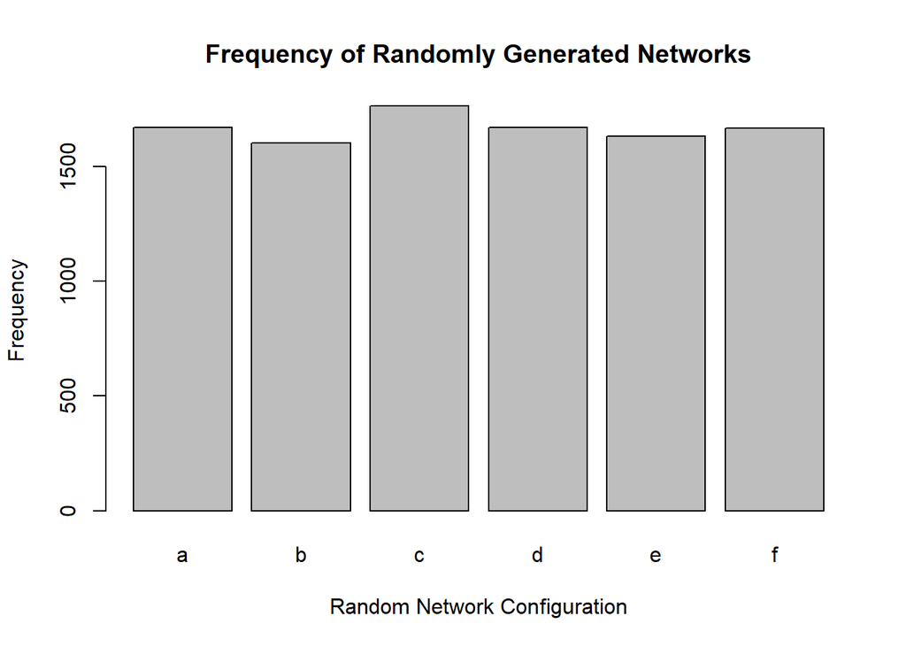

```r
##Checking that the random networks are about uniformly distributed
test = c(3,2,2,2,1)
test.nets = config.valid.networks(test,10000)
test.unique = unique(test.nets)
a = test.unique[[1]]
b = test.unique[[2]]
c = test.unique[[3]]
d = test.unique[[4]]
e = test.unique[[5]]
f = test.unique[[6]]

test.dist = c()
for (i in 1:length(test.nets))
{
  if (identical(test.nets[[i]], a))
  {
    test.dist = c(test.dist, "a")
  }
  if (identical(test.nets[[i]], b))
  {
    test.dist = c(test.dist, "b")
  }
  if (identical(test.nets[[i]], c))
  {
    test.dist = c(test.dist, "c")
  }
  if (identical(test.nets[[i]], d))
  {
    test.dist = c(test.dist, "d")
  }
  if (identical(test.nets[[i]], e))
  {
    test.dist = c(test.dist, "e")
  }
  if (identical(test.nets[[i]], f))
  {
    test.dist = c(test.dist, "f")
  }
}

barplot(height = table(test.dist), main = "Frequency of Randomly Generated Networks", xlab = "Random Network Configuration", ylab = "Frequency")
```